# Lettosuo_Gradu

Gopal Adhikari

28 11 2021

# 1 Introduction

## 1.1 Background

## 1.2 Research aims

## 1.3 Reaearch questions

- How strongly partial harvest impacts ground floor GPP?
- How different plant community response to PAR?
- Does GPP in different chambers varies significantly, and what are the reasons behind?
- How forest floor GPP of partial harvest and control sites respond to changing climatic variables?

# 2 Material and method

## 2.1 Lettosuo (Location, past and present conditions)

## 2.2 GPP, NEE and Respiration(where? when? how? why?)

# 3 Data analysis and results

```r
library(dplyr)
```

```r
library(ggplot2)
library(corrplot)
library(GGally)
library(gridExtra)
library(lubridate)
library(xts)
```

## 3.1 Data importing and sorting(GPP, Precipitation, LAI)

loading data

```r
control_ch <- read.csv("finaldata/c_chambers.csv", header = TRUE, sep = ",", dec = ".", row.names = 1)

partialh_ch <- read.csv("finaldata/ph_chambers.csv", header = TRUE, sep = ",", dec = ".", row.names = 1)

precipitation <- read.csv("CSV/rain.csv", header = TRUE, sep = ",", dec = ".")

rain16.17 <- read.csv("CSV/rain16_17.csv", header = TRUE, sep = ",", dec = ".", row.names = 1)

lai <- read.csv("CSV/lai_data.csv", header = TRUE, sep = ";", dec = ",")
```

- **Research Questions**
- How strongly partial harvest impacts ground floor GPP?
- How different plant community response to PAR?
- Does GPP in different chambers varies significantly, and what are the reasons behind?
- How forest floor GPP of partial harvest and control sites respond to changing climatic variables?

I combined all six chambers measurements from both control and partial harvest site in to this file.

structure and summary

```r
str(control_ch)
```

```
## 'data.frame':    52722 obs. of  13 variables:
##  $ Chambers                             : chr  "c_ch1" "c_ch1" "c_ch1" "c_ch1" ...
##  $ Date                                 : chr  "2015-06-01 00:00:00" "2015-06-01 01:00:00" "2015-06-01 02:00:00" "2015-06-01 03:00:00" ...
##  $ Modelled.respiration..mg.co2.m.2.h.1.: num  360 350 341 334 330 ...
##  $ Modelled.GPP..mg.co2.m.2.h.1.        : num  NA 0 0 0 -0.011 ...
##  $ Measured.NEE..mg.co2.m.2.h.1.        : num  NA NA NA NA NA NA NA NA NA NA ...
##  $ Measured.respiration..mg.co2.m.2.h.1.: num  NA NA NA NA NA NA NA NA NA NA ...
##  $ PAR..umol.m.2.s.1.                   : num  3.38 3.38 3.39 3.62 5.52 ...
##  $ Headspace.temperature..C.            : num  NA NA NA NA NA NA NA NA NA NA ...
##  $ Soil.surface.temperature..C.         : num  NA NA NA NA NA NA NA NA NA NA ...
##  $ X2.cm.soil.temperature..C.           : num  NA NA NA NA NA NA NA NA NA NA ...
##  $ X5.cm.soil.temperature..C.           : num  NA NA NA NA NA NA NA NA NA NA ...
##  $ X20.cm.soil.temperature..C.          : num  NA NA NA NA NA NA NA NA NA NA ...
##  $ X30.cm.soil.temperature..C.          : num  NA NA NA NA NA NA NA NA NA NA ...
```

```r
summary(control_ch)
```

```
##    Chambers             Date           Modelled.respiration..mg.co2.m.2.h.1.
##  Length:52722       Length:52722       Min.   :  97.38
##  Class :character   Class :character   1st Qu.: 413.38
##  Mode  :character   Mode  :character   Median : 545.04
##                                        Mean   : 548.57
##                                        3rd Qu.: 675.36
##                                        Max.   :1214.16
##
##  Modelled.GPP..mg.co2.m.2.h.1. Measured.NEE..mg.co2.m.2.h.1.
##  Min.   :-0.07587              Min.   :-2082.9
##  1st Qu.:-0.01305              1st Qu.:  399.3
##  Median :-0.00142              Median :  519.7
##  Mean   :-0.00728              Mean   :  534.7
##  3rd Qu.: 0.00000              3rd Qu.:  655.1
##  Max.   : 0.00000              Max.   : 1928.1
##  NA's   :36                    NA's   :17735
##  Measured.respiration..mg.co2.m.2.h.1. PAR..umol.m.2.s.1.
##  Min.   : 131.9                        Min.   : -0.3475
##  1st Qu.: 429.5                        1st Qu.:  1.2937
##  Median : 572.4                        Median :  6.5612
##  Mean   : 550.6                        Mean   : 16.5238
##  3rd Qu.: 664.0                        3rd Qu.: 21.3494
##  Max.   :1276.4                        Max.   :987.2406
##  NA's   :44712
##  Headspace.temperature..C. Soil.surface.temperature..C.
##  Min.   :-1.299            Min.   : 2.322
##  1st Qu.:10.256            1st Qu.:10.581
##  Median :13.315            Median :12.863
##  Mean   :13.071            Mean   :12.629
##  3rd Qu.:15.972            3rd Qu.:14.870
##  Max.   :27.491            Max.   :22.761
##  NA's   :8322              NA's   :8328
##  X2.cm.soil.temperature..C. X5.cm.soil.temperature..C.
##  Min.   : 3.946             Min.   : 4.959
##  1st Qu.:10.791             1st Qu.:10.672
##  Median :12.702             Median :12.090
##  Mean   :12.495             Mean   :11.979
##  3rd Qu.:14.358             3rd Qu.:13.393
##  Max.   :19.132             Max.   :16.491
##  NA's   :8322               NA's   :8322
##  X20.cm.soil.temperature..C. X30.cm.soil.temperature..C.
##  Min.   : 5.32               Min.   : 4.284
##  1st Qu.:10.10               1st Qu.: 9.404
##  Median :11.35               Median :10.693
##  Mean   :10.96               Mean   :10.227
##  3rd Qu.:12.11               3rd Qu.:11.404
##  Max.   :13.70               Max.   :12.453
##  NA's   :8448                NA's   :8322
```

```r
str(partialh_ch)
```

```
## 'data.frame':    95490 obs. of  14 variables:
##  $ Chambers                             : chr  "ph_ch1" "ph_ch1" "ph_ch1" "ph_ch1" ...
##  $ Date                                 : chr  "2013-05-15 00:00:00" "2013-05-15 01:00:00" "2013-05-15 02:00:00" "2013-05-15 03:00:00" ...
##  $ Modelled.respiration..mg.co2.m.2.h.1.: num  210 206 201 196 191 ...
##  $ Modelled.GPP..mg.co2.m.2.h.1.        : num  NA 0 0 0 -0.0201 ...
##  $ Measured.NEE..mg.co2.m.2.h.1.        : num  107.9 NA NA NA 15.2 ...
##  $ Measured.respiration..mg.co2.m.2.h.1.: num  NA NA NA NA NA NA NA NA NA NA ...
##  $ PAR..umol.m.2.s.1.                   : num  11.5 11.5 11.6 11.6 15.6 ...
##  $ Headspace.temperature..C.            : num  6.12 4.15 4.54 2.68 1.62 ...
##  $ Soil.surface.temperature..C.         : num  5.6 4.26 4.15 3.08 2.24 ...
##  $ X2.cm.soil.temperature..C.           : num  6.77 6.13 5.78 5.32 4.76 ...
##  $ X5.cm.soil.temperature..C.           : num  6.81 6.65 6.44 6.26 6.04 ...
##  $ X10.cm.soil.temperature..C.          : num  5.8 5.76 5.71 5.64 5.57 ...
##  $ X20.cm.soil.temperature..C.          : num  5.04 5.04 5.04 5.03 5.01 ...
##  $ X30.cm.soil.temperature..C.          : num  3.82 3.82 3.83 3.84 3.85 ...
```

```r
summary(partialh_ch)
```

```
##    Chambers             Date           Modelled.respiration..mg.co2.m.2.h.1.
##  Length:95490       Length:95490       Min.   :  59.8
##  Class :character   Class :character   1st Qu.: 378.1
##  Mode  :character   Mode  :character   Median : 501.1
##                                        Mean   : 509.1
##                                        3rd Qu.: 643.0
##                                        Max.   :1888.6
##                                        NA's   :2137
##  Modelled.GPP..mg.co2.m.2.h.1. Measured.NEE..mg.co2.m.2.h.1.
##  Min.   :-0.311                Min.   :-2.234e+18
##  1st Qu.:-0.020                1st Qu.: 3.420e+02
##  Median : 0.000                Median : 4.950e+02
##  Mean   :-0.014                Mean   :-4.509e+13
##  3rd Qu.: 0.000                3rd Qu.: 6.560e+02
##  Max.   : 0.000                Max.   : 2.408e+09
##  NA's   :3252                  NA's   :35356
##  Measured.respiration..mg.co2.m.2.h.1. PAR..umol.m.2.s.1.
##  Min.   : -85.95                       Min.   :   0.0263
##  1st Qu.: 343.52                       1st Qu.:   1.9879
##  Median : 464.00                       Median :  14.3380
##  Mean   : 470.46                       Mean   :  39.5029
##  3rd Qu.: 589.61                       3rd Qu.:  49.8775
##  Max.   :1371.52                       Max.   :1610.3748
##  NA's   :81210
##  Headspace.temperature..C. Soil.surface.temperature..C.
##  Min.   :-8.009            Min.   :-2.277
##  1st Qu.: 9.173            1st Qu.:10.014
##  Median :12.856            Median :12.840
##  Mean   :12.715            Mean   :12.527
##  3rd Qu.:16.346            3rd Qu.:15.366
##  Max.   :29.877            Max.   :24.958
##  NA's   :7290              NA's   :7290
##  X2.cm.soil.temperature..C. X5.cm.soil.temperature..C.
##  Min.   :-0.393             Min.   : 0.674
##  1st Qu.: 9.205             1st Qu.:10.014
##  Median :11.388             Median :11.840
##  Mean   :11.131             Mean   :11.435
##  3rd Qu.:13.199             3rd Qu.:13.326
##  Max.   :19.748             Max.   :17.819
##  NA's   :7290               NA's   :7290
##  X10.cm.soil.temperature..C. X20.cm.soil.temperature..C.
##  Min.   : 0.992              Min.   : 0.878
##  1st Qu.: 9.687              1st Qu.: 9.195
##  Median :11.491              Median :11.014
##  Mean   :11.032              Mean   :10.502
##  3rd Qu.:12.833              3rd Qu.:12.233
##  Max.   :16.595              Max.   :15.331
##  NA's   :7290                NA's   :7290
##  X30.cm.soil.temperature..C.
##  Min.   : 1.072
##  1st Qu.: 8.880
##  Median :10.589
##  Mean   : 9.985
##  3rd Qu.:11.503
##  Max.   :16.330
##  NA's   :7290
```

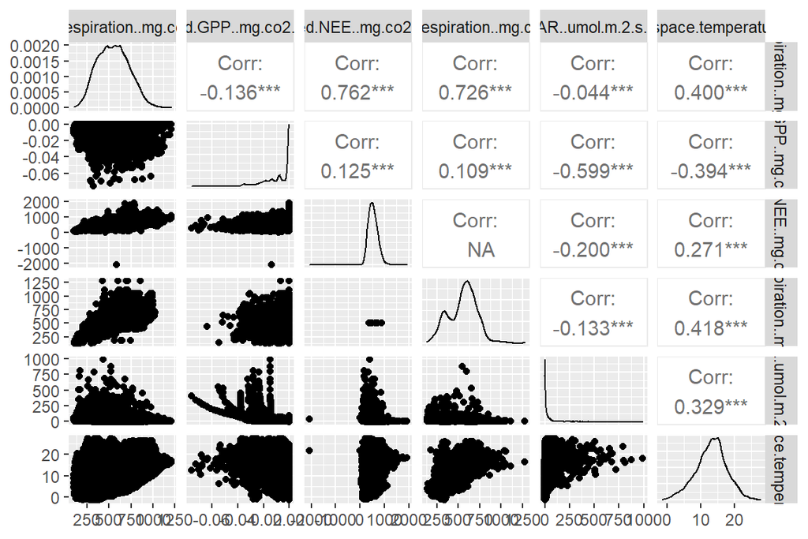

```r
ggpairs(control_ch[3:8], lower = list(combo = wrap("facethist", bins = 20)))
```

```r
control_ch$Chambers <- factor(control_ch$Chambers)

partialh_ch$Chambers <- factor(partialh_ch$Chambers)
```

I create separate date variables for daily, monthly and yearly average calculations

```r
control_ch$daily <- day(control_ch$Date)
control_ch$monthly <- month(control_ch$Date)
control_ch$yearly <- year(control_ch$Date)
```

```r
partialh_ch$daily <- day(partialh_ch$Date)
partialh_ch$monthly <- month(partialh_ch$Date)
partialh_ch$yearly <- year(partialh_ch$Date)
```

GPP calculated from measured NEE and modeled R

```r
control_ch$caculatedGPP <- - control_ch$Measured.NEE..mg.co2.m.2.h.1. + control_ch$Modelled.respiration..mg.co2.m.2.h.1.
partialh_ch$caculatedGPP <- - partialh_ch$Measured.NEE..mg.co2.m.2.h.1. + partialh_ch$Modelled.respiration..mg.co2.m.2.h.1.
```

Lets compare monthly mean gpp of both sites for entire experiments

- **calculated**

```r
control_ch %>% group_by(monthly) %>% summarise(mean1 = mean(caculatedGPP, na.rm = TRUE))
```

```
## # A tibble: 5 x 2
##   monthly  mean1
##     <dbl>  <dbl>
## 1       6  22.1
## 2       7  15.8
## 3       8  27.6
## 4       9  -9.96
## 5      10 -59.0
```

- **modeled**

```r
control_ch %>% group_by(monthly) %>% summarise(mean1 = mean(Modelled.GPP..mg.co2.m.2.h.1., na.rm = TRUE))
```

```
## # A tibble: 5 x 2
##   monthly     mean1
##     <dbl>     <dbl>
## 1       6  -0.00897
## 2       7  -0.00814
## 3       8  -0.00686
## 4       9  -0.00514
## 5      10 NaN
```

Here I repeat same calculations for partial harvest chambers

```r
partialh_ch %>% group_by(monthly) %>% summarise(mean1 = mean(caculatedGPP, na.rm = TRUE))
```

```
## # A tibble: 7 x 2
##   monthly      mean1
##     <dbl>      <dbl>
## 1       5   6.91e+14
## 2       6   5.51e+ 1
## 3       7  -3.85e+ 2
## 4       8  -1.84e+ 5
## 5       9   5.21e- 1
## 6      10  -6.38e- 1
## 7      11 NaN
```

```r
partialh_ch %>% group_by(monthly) %>% summarise(mean1 = mean(Modelled.GPP..mg.co2.m.2.h.1., na.rm = TRUE))
```

```
## # A tibble: 7 x 2
##   monthly     mean1
##     <dbl>     <dbl>
## 1       5  -0.00754
## 2       6  -0.0184
## 3       7  -0.0175
## 4       8  -0.0134
## 5       9  -0.0105
## 6      10  -0.00239
## 7      11 NaN
```

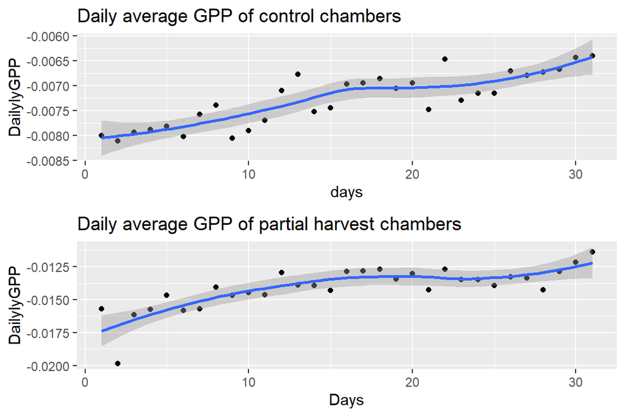

```r
dailygpp <- tibble(control_ch %>% group_by(daily) %>%
  summarise(mean1 = mean(Modelled.GPP..mg.co2.m.2.h.1., na.rm = TRUE)))

p1 <- ggplot(dailygpp, aes(x = daily, y = mean1)) +
   geom_point() +
  geom_smooth() +
  labs(x= "days", y = "DailylyGPP", title = "Daily average GPP of control chambers")

dailygppph <- tibble(partialh_ch %>% group_by(daily) %>%
  summarise(mean1 = mean(Modelled.GPP..mg.co2.m.2.h.1., na.rm = TRUE)))

p2 <- ggplot(dailygppph, aes(x = daily, y = mean1)) +
  geom_point() +
   geom_smooth() +
  labs(x= "Days", y = "DailylyGPP", title = "Daily average GPP of partial harvest chambers")


library(gridExtra)

grid.arrange(p1, p2, ncol = 1, nrow =2)
```

Lets look at average daily gpp for each months separately

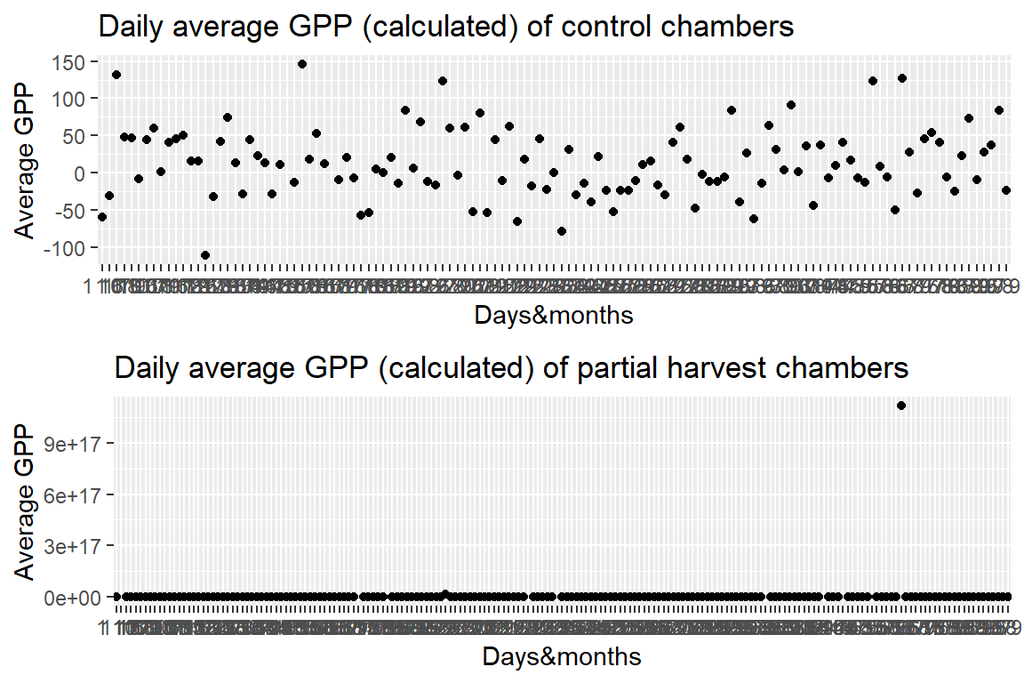

```r
control_ch$daily_monthly <- paste(control_ch$daily, control_ch$monthly)
partialh_ch$daily_monthly <- paste(partialh_ch$daily, partialh_ch$monthly)


dailygpp <- tibble(control_ch %>% group_by(daily_monthly) %>%
  summarise(mean1 = mean(caculatedGPP, na.rm = TRUE)))

p3 <- ggplot(dailygpp, aes(daily_monthly, mean1)) +
  geom_point() +
  labs(x= "Days&months", y = "Average GPP", title = "Daily average GPP (calculated) of control chambers")

phdailygpp <- tibble(partialh_ch %>% group_by(daily_monthly) %>%
  summarise(mean1 = mean(caculatedGPP, na.rm = TRUE)))

p4 <- ggplot(phdailygpp, aes(daily_monthly, mean1)) +
  geom_point() +
  labs(x= "Days&months", y = "Average GPP", title = "Daily average GPP (calculated) of partial harvest chambers")

grid.arrange(p3, p4, ncol = 1, nrow = 2)
```

Some figures and statistics on GPP of different chambers

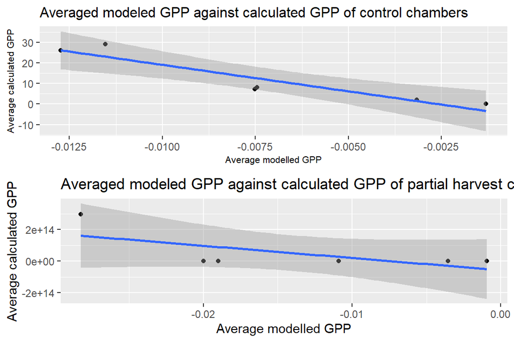

```r
controlch_avg <-tibble(control_ch %>% group_by(Chambers) %>% summarise(mean1 = mean(Modelled.GPP..mg.co2.m.2.h.1., na.rm = TRUE), mean2 = mean(caculatedGPP, na.rm = TRUE)))

p5 <- ggplot(controlch_avg, aes(mean1, mean2)) +
  geom_point() +
  geom_smooth(method = "lm") +
  theme(axis.title.x = element_text( size = 8),
axis.title.y = element_text(size = 8), plot.title = element_text(size=12)) +
  labs(x= "Average modelled GPP", y = "Average calculated GPP", title = "Averaged modeled GPP against calculated GPP of control chambers")

partialchavg <- tibble(partialh_ch %>% group_by(Chambers) %>% summarise(meanmo = mean(Modelled.GPP..mg.co2.m.2.h.1., na.rm = TRUE), meancal = mean(caculatedGPP, na.rm = TRUE)))

p6 <- ggplot(partialchavg, aes(meanmo, meancal)) +
  geom_point() +
  geom_smooth(method = "lm") +
  labs(x= "Average modelled GPP", y = "Average calculated GPP", title = "Averaged modeled GPP against calculated GPP of partial harvest chambers")

grid.arrange(p5, p6, ncol = 1, nrow =2)
```

## 3.2 Precipitation, PAR, LAI, Temperature and GPP

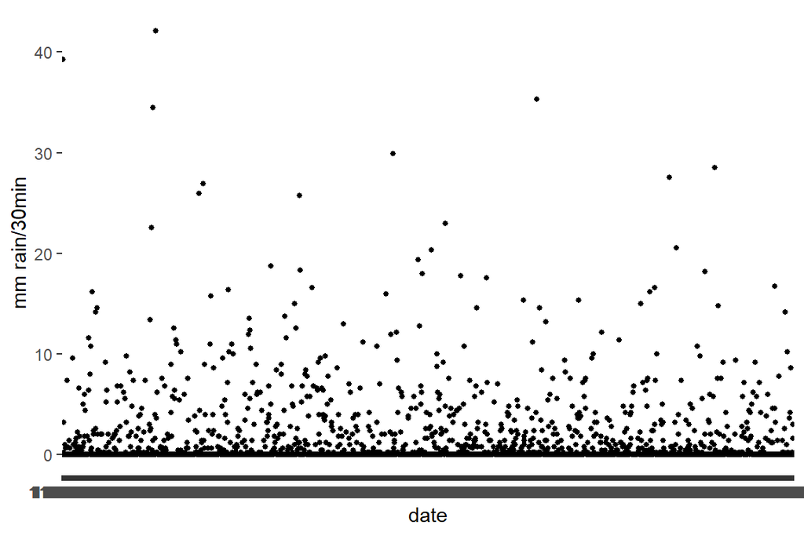

```r
precipitation30min <- precipitation %>% select(Date, Lettosuo.Precipitation.Screend.mm.30min.1.)
colnames(precipitation30min) <- c("Date", "rain.mm.30.min.1")
precipitation30min <- precipitation30min %>% mutate(Date = dmy_hm(Date))
colnames(rain16.17) <- c("Date", "rain.mm.30.min.1")

rain10.17 <- rbind(precipitation30min, rain16.17)

rain13_18 <- rain10.17 %>% filter(Date > "2013-05-15 00:00:00")


precipitation30min$daily <- day(precipitation30min$Date)
precipitation30min$monthly <- month(precipitation30min$Date)
precipitation30min$yearly <- year(precipitation30min$Date)
precipitation30min$dailymy <- paste(precipitation30min$daily, precipitation30min$monthly, precipitation30min$yearly)

dailygpp <- tibble(control_ch %>% group_by(daily) %>%
  summarise(mean1 = mean(Modelled.GPP..mg.co2.m.2.h.1., na.rm = TRUE)))

pre <- precipitation30min %>% group_by(dailymy) %>% summarise(dailyrain = sum(rain.mm.30.min.1, na.rm = TRUE))

p7 <- ggplot(pre, aes(dailymy, dailyrain)) +
  geom_point(size = 1) +
  labs(x = "date", y = "mm rain/30min")
p7
```

```r
str(lai)
```

```
## 'data.frame':    38 obs. of  5 variables:
##  $ date: chr  "28.4.2011" "10.5.2011" "18.5.2011" "24.5.2011" ...
##  $ ch1 : num  0.189 0.19 0.238 0.466 1.104 ...
##  $ ch2 : num  0.00945 0.01565 0.0965 0.26487 0.6774 ...
##  $ ch4 : num  0.215 0.217 0.336 0.423 1.712 ...
##  $ ch5 : num  0 0 0.0129 0.0391 0.0963 ...
```

```r
nd <- c("2011-04-28", "2011-05-10", "2011-05-18", "2011-05-24", "2011-06-07", "2011-06-10", "2011-06-22", "2011-07-29", "2011-08-11",
        "2011-08-18", "2011-08-25", "2011-09-06", "2011-09.20", "2011-10-03", "2011-10-13", "2011-11-01", "2011-11-16", "2011-11-29",
        "2012-05-03", "2012-05-14", "2012-05-21", "2012-06-08", "2012-06-18", "2012-07-02", "2012-08-09", "2012-08-24", "2012-09-11",
        "2012-10-02", "2012-10-18", "2012-11-20", "2013-05-15", "2013-05-31", "2013-06-13", "2013-06-28", "2013-07-19", "2013-08-30",
        "2013-09-20", "2013-10-24")
lai$date <- nd
lai$date <- as.Date(lai$date)

m1 <- lm(ch1 ~ date + ch2 + ch4 + ch5, data = lai)
summary(m1)
```

```
##
## Call:
## lm(formula = ch1 ~ date + ch2 + ch4 + ch5, data = lai)
##
## Residuals:
##      Min       1Q   Median       3Q      Max
## -0.42958 -0.05717  0.02002  0.07297  0.39585
##
## Coefficients:
##               Estimate Std. Error t value Pr(>|t|)
## (Intercept) -2.8689720  1.6502308  -1.739   0.0917 .
## date         0.0001934  0.0001071   1.806   0.0804 .
## ch2         -0.0142145  0.3380836  -0.042   0.9667
## ch4          0.3051339  0.0655071   4.658 5.35e-05 ***
## ch5          8.7067443  1.9063135   4.567 6.96e-05 ***
## ---
## Signif. codes:  0 '***' 0.001 '**' 0.01 '*' 0.05 '.' 0.1 ' ' 1
##
## Residual standard error: 0.1783 on 32 degrees of freedom
##   (1 observation deleted due to missingness)
## Multiple R-squared:  0.8941, Adjusted R-squared:  0.8809
## F-statistic: 67.55 on 4 and 32 DF,  p-value: 3.826e-15
```

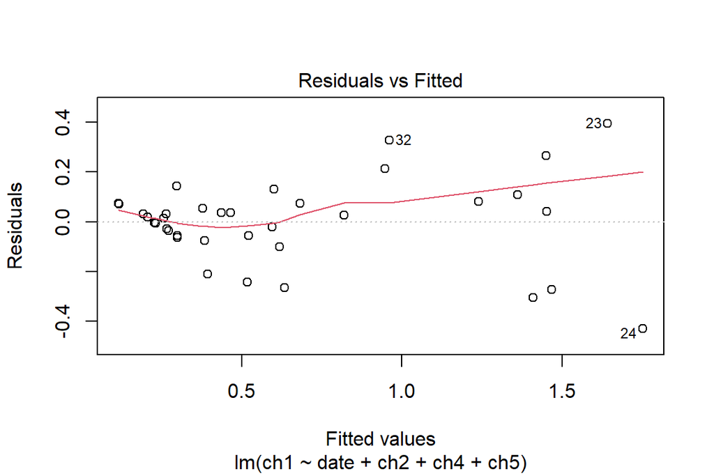

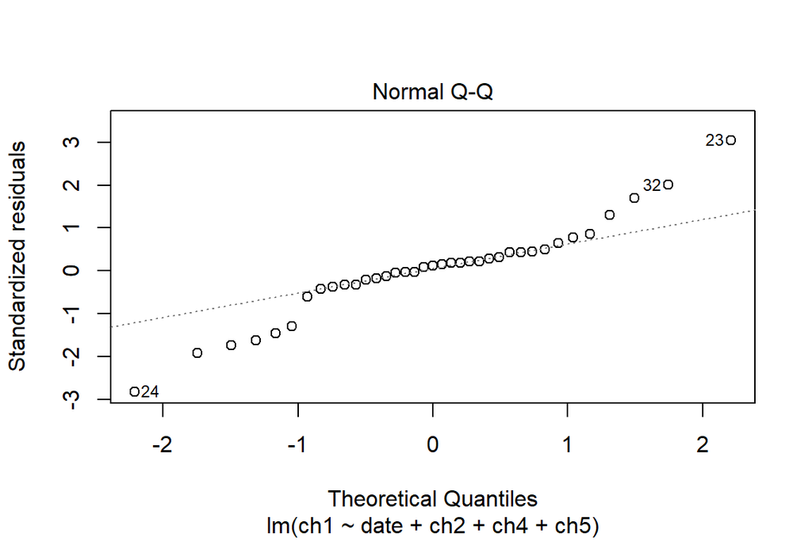

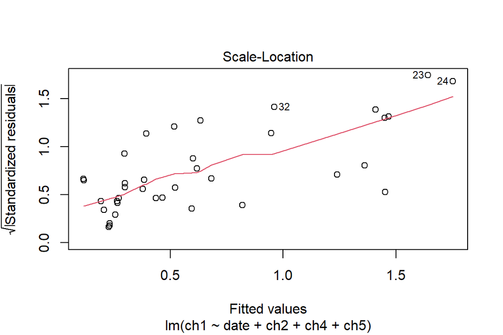

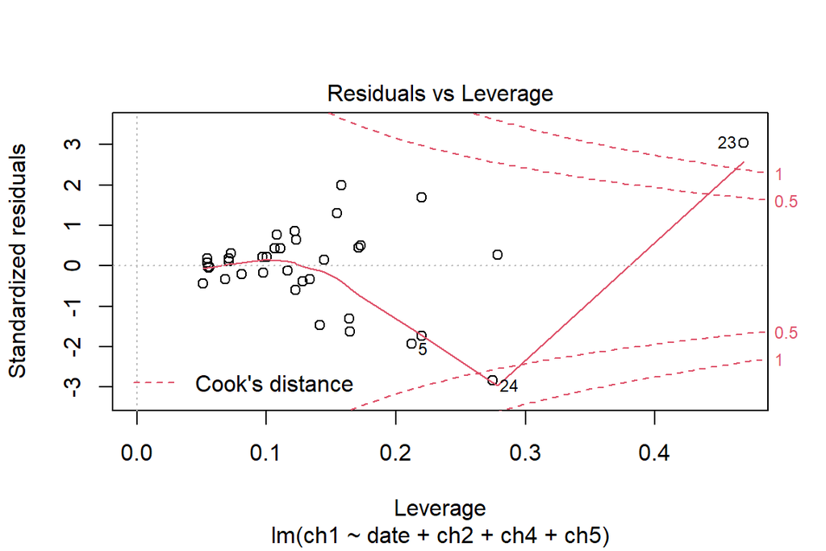

```r
plot(m1)
```

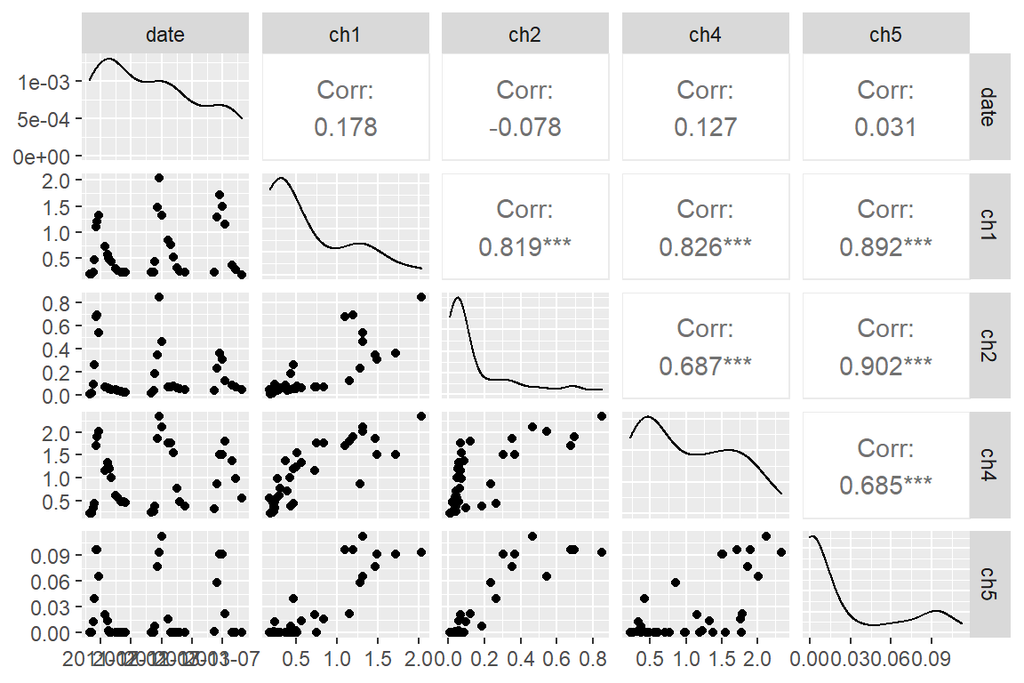

```r
ggpairs(lai)
```

## 3.3 GPP in Controlled and partial harvest plots

## 3.4 Some durnal, seasonal and yearly varaitions

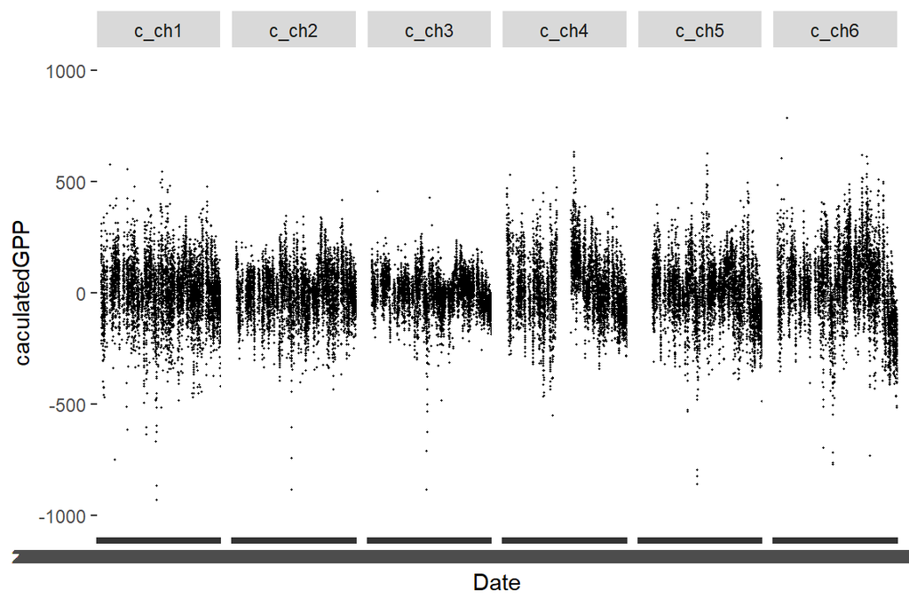

```r
ggplot(control_ch, aes(Date, caculatedGPP)) +
  geom_point(size = 0.2) +
  ylim(-1000, 1000) +
  facet_grid(. ~ Chambers)
```

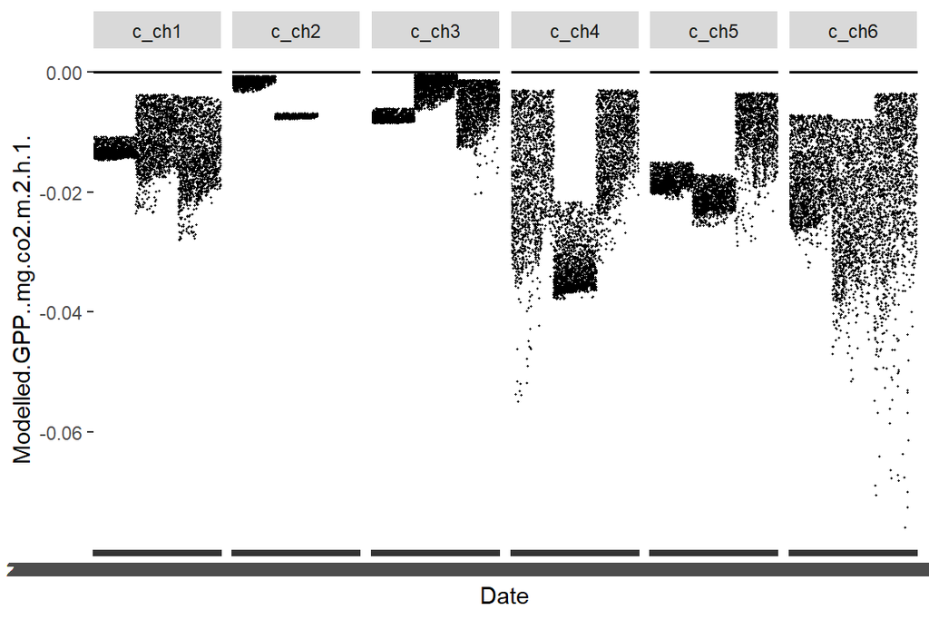

```r
ggplot(control_ch, aes(Date, Modelled.GPP..mg.co2.m.2.h.1.)) +
  geom_point(size = 0.2) +
  facet_grid(. ~ Chambers)
```

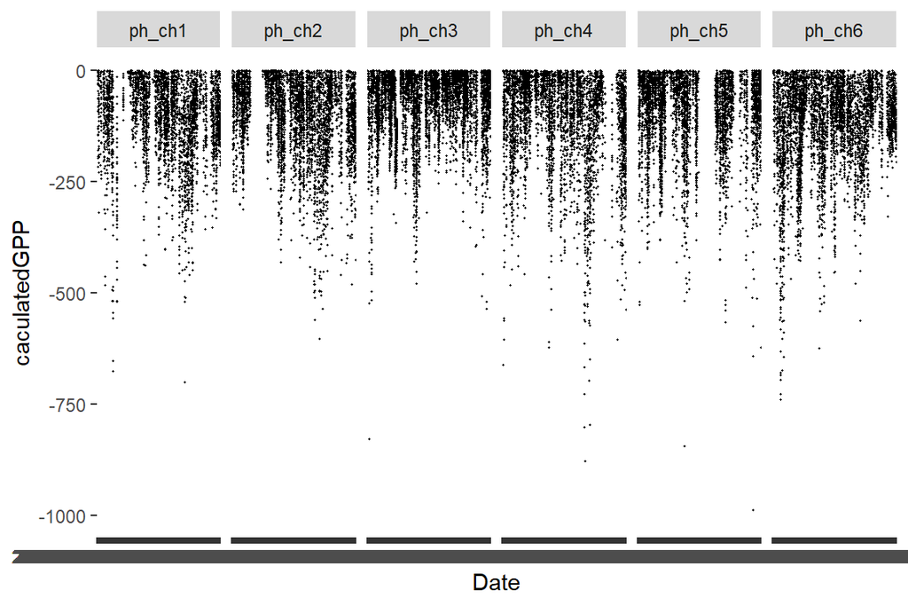

```r
ggplot(partialh_ch, aes(Date, caculatedGPP)) +
  geom_point(size = 0.2) +
  ylim(-1000, 0) +
  facet_grid(. ~ Chambers)
```

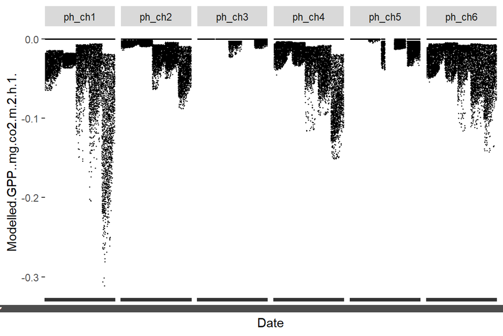

```r
ggplot(partialh_ch, aes(Date, Modelled.GPP..mg.co2.m.2.h.1.)) +
  geom_point(size = 0.2) +
  facet_grid(. ~ Chambers)
```

GPP = NEE-R

```r
control_ch$NEE_R <- control_ch$Measured.NEE..mg.co2.m.2.h.1. - control_ch$Modelled.respiration..mg.co2.m.2.h.1.
partialh_ch$NEE_R <- partialh_ch$Measured.NEE..mg.co2.m.2.h.1. - partialh_ch$Modelled.respiration..mg.co2.m.2.h.1.
```

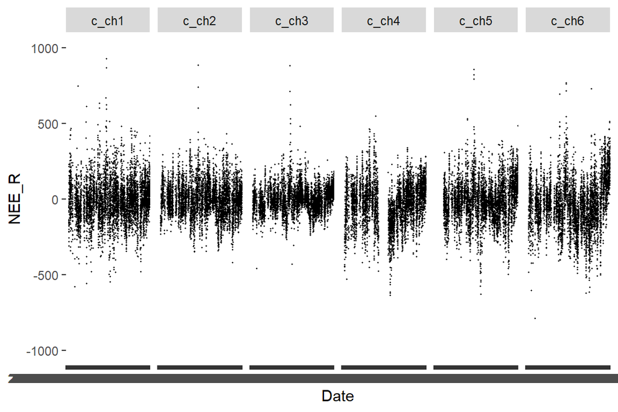

```r
ggplot(control_ch, aes(Date, NEE_R)) +
  geom_point(size = 0.2) +
  ylim(-1000, 1000) +
  facet_grid(. ~ Chambers)
```

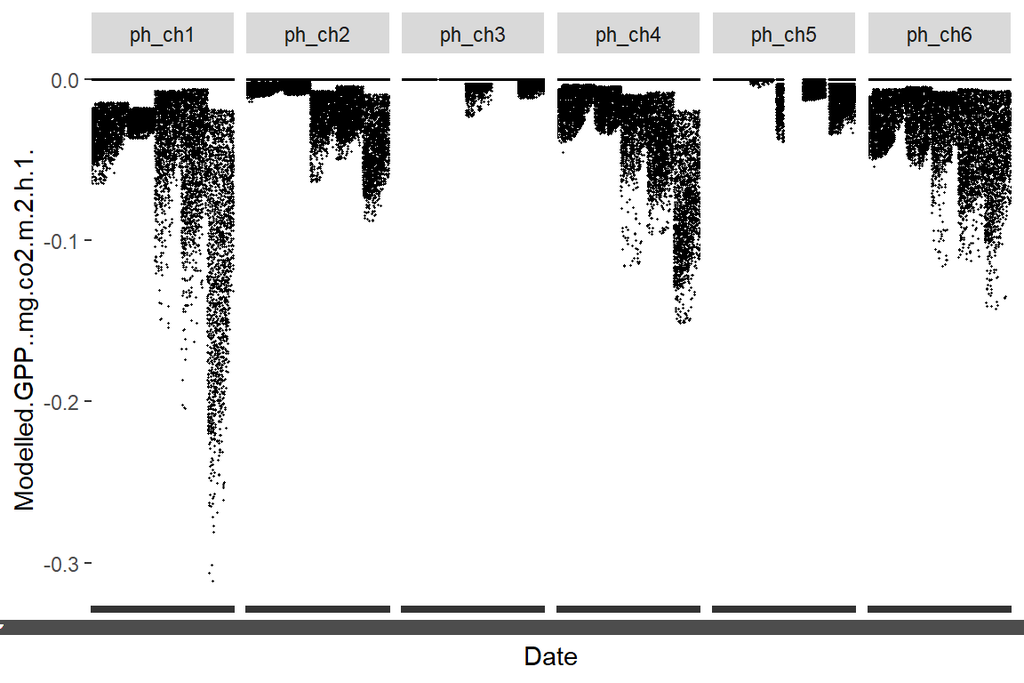

```r
ggplot(partialh_ch, aes(Date, Modelled.GPP..mg.co2.m.2.h.1.)) +
  geom_point(size = 0.2) +
  facet_grid(. ~ Chambers)
```

# 4 Results

# 5 Discussion

# 6 Consulion

# 7 References